# Exercise 2_1: Vector Data Refresher

Advanced Geospatial Data Processing for Social Scientists

Author

Dennis Abel & Stefan Jünger

In these three exercises, you’ll refresh your knowledge about geospatial vector data using `R`. We’ll start with some basics on importing and handling vector data, and then explore how to link datasets together — even when the data doesn’t always match perfectly.

Along the way, you’ll have the chance to explore, experiment, and solve problems that come up, like working with different coordinate reference systems (CRS).

Let’s get started and have some fun with spatial data! 🌍✨

### Exercises

**Note🏋️ Exercise 1**

Import a polygon vector shapefile from the `./data` folder. After loading, explore it:

- How many features are there? What attributes are included?
- What is the coordinate reference system (CRS)?
- Have a look at the `GF` column — it contains different values. What could they mean, and how many unique geometries do you actually have?
- Feel free to plot the data for a first visual impression!

**Caution💡 Tip**

Shapefiles include a file with the extension `.shp`. You can use the `sf` package and the `sf::st_read()` function to import the data. Hint: If you want a cleaner output, you can set `quiet = TRUE`.

The `GF` column encodes the geometry type (e.g., land vs. water boundaries). Try `table(data$GF)` to see the distribution — you may want to filter for one type!

**Note🏋️ Exercise 2**

**Caution💡 Tip**

**Note🏋️ Exercise 3**

**Caution💡 Tip**

Beware: The coordinate reference systems (CRS) of the two datasets are different! Make sure they match before trying to perform the spatial join — otherwise, you might get an error (and that’s totally fine — part of the learning!).

- Check the CRS of both datasets with `sf::st_crs()`.
- Use `sf::st_transform()` to bring one dataset into the CRS of the other.
- For the join, you can use `sf::st_join()`.

You could also transform the polygons instead of the points — it depends on what fits better. Always double-check that geometries line up properly after transformation (e.g., by plotting)!

### Solutions

**Tip✅ Solution 1**

```r
library(sf)

# Load the German districts shapefile
polygon_data <- sf::st_read("./data/VG250_KRS.shp", quiet = TRUE)

# Basic inspection — how big is the dataset?
print(polygon_data) # overview: columns, geometry type, CRS
nrow(polygon_data) # number of features (rows)
sf::st_crs(polygon_data) # coordinate reference system

# The GF column contains geometry type codes
# GF = 4 means land boundaries (what we usually want)
table(polygon_data$GF) # how many of each type?

# Visualize the geometry (without attributes)
plot(sf::st_geometry(polygon_data))
```

```
Simple feature collection with 431 features and 23 fields
Geometry type: MULTIPOLYGON
Dimension:     XY
Bounding box:  xmin: 280371.1 ymin: 5235856 xmax: 921292.4 ymax: 6101487
Projected CRS: ETRS89 / UTM zone 32N
First 10 features:
   ADE GF BSG   ARS   AGS      SDV_ARS                 GEN              BEZ IBZ
1    4  4   1 01001 01001 010010000000           Flensburg Kreisfreie Stadt  40
2    4  4   1 01002 01002 010020000000                Kiel Kreisfreie Stadt  40
3    4  4   1 01003 01003 010030000000              Lübeck Kreisfreie Stadt  40
4    4  4   1 01004 01004 010040000000          Neumünster Kreisfreie Stadt  40
5    4  4   1 01051 01051 010510044044        Dithmarschen            Kreis  42
6    4  4   1 01053 01053 010530100100 Herzogtum Lauenburg            Kreis  42
7    4  4   1 01054 01054 010540056056       Nordfriesland            Kreis  42
8    4  4   1 01055 01055 010550012012         Ostholstein            Kreis  42
```

[output cut: 24 more lines]

```
[1] 431
```

```
Coordinate Reference System:
  User input: ETRS89 / UTM zone 32N
  wkt:
PROJCRS["ETRS89 / UTM zone 32N",
    BASEGEOGCRS["ETRS89",
        ENSEMBLE["European Terrestrial Reference System 1989 ensemble",
            MEMBER["European Terrestrial Reference Frame 1989"],
            MEMBER["European Terrestrial Reference Frame 1990"],
            MEMBER["European Terrestrial Reference Frame 1991"],
            MEMBER["European Terrestrial Reference Frame 1992"],
            MEMBER["European Terrestrial Reference Frame 1993"],
            MEMBER["European Terrestrial Reference Frame 1994"],
            MEMBER["European Terrestrial Reference Frame 1996"],
            MEMBER["European Terrestrial Reference Frame 1997"],
            MEMBER["European Terrestrial Reference Frame 2000"],
            MEMBER["European Terrestrial Reference Frame 2005"],
            MEMBER["European Terrestrial Reference Frame 2014"],
            MEMBER["European Terrestrial Reference Frame 2020"],
            ELLIPSOID["GRS 1980",6378137,298.257222101,
                LENGTHUNIT["metre",1]],
            ENSEMBLEACCURACY[0.1]],
        PRIMEM["Greenwich",0,
            ANGLEUNIT["degree",0.0174532925199433]],
        ID["EPSG",4258]],
    CONVERSION["UTM zone 32N",
        METHOD["Transverse Mercator",
            ID["EPSG",9807]],
        PARAMETER["Latitude of natural origin",0,
            ANGLEUNIT["degree",0.0174532925199433],
            ID["EPSG",8801]],
        PARAMETER["Longitude of natural origin",9,
            ANGLEUNIT["degree",0.0174532925199433],
            ID["EPSG",8802]],
        PARAMETER["Scale factor at natural origin",0.9996,
            SCALEUNIT["unity",1],
            ID["EPSG",8805]],
        PARAMETER["False easting",500000,
            LENGTHUNIT["metre",1],
            ID["EPSG",8806]],
        PARAMETER["False northing",0,
            LENGTHUNIT["metre",1],
            ID["EPSG",8807]]],
    CS[Cartesian,2],
        AXIS["(E)",east,
            ORDER[1],
            LENGTHUNIT["metre",1]],
        AXIS["(N)",north,
            ORDER[2],
            LENGTHUNIT["metre",1]],
    USAGE[
        SCOPE["Engineering survey, topographic mapping."],
        AREA["Europe between 6°E and 12°E: Austria; Denmark - onshore and offshore; Germany - onshore and offshore; Italy - onshore and offshore; Norway including Svalbard - onshore and offshore; Spain - offshore."],
        BBOX[36.53,6,84.01,12.01]],
    USAGE[
        SCOPE["Pan-European conformal mapping at scales larger than 1:500,000."],
        AREA["Europe between 6°E and 12°E and approximately 36°30'N to 84°N."],
        BBOX[36.53,6,84.01,12.01]],
    ID["EPSG",25832]]
```

```
  2   4
 30 401
```

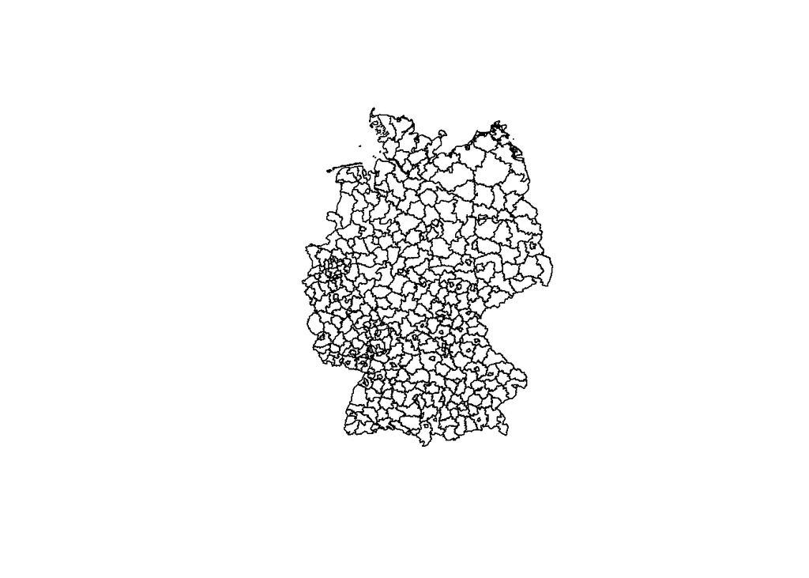

**Tip✅ Solution 2**

```r
library(sf)
library(readr)

# Load as plain data frame — no geometry yet!
coords_df <- read_csv("./data/synthetic_geocoordinates.csv")
head(coords_df) # inspect: which columns hold coordinates?

# Convert to sf: specify coordinate columns and CRS
# The x/y columns are in EPSG:3035 (ETRS89-LAEA, meters)
points_sf <-
  sf::st_as_sf(
    coords_df,
    coords = c("x", "y"), # coordinate columns
    crs = 3035 # ETRS89-LAEA (Europe equal-area)
  )

# Now it's a proper spatial object
plot(points_sf)
```

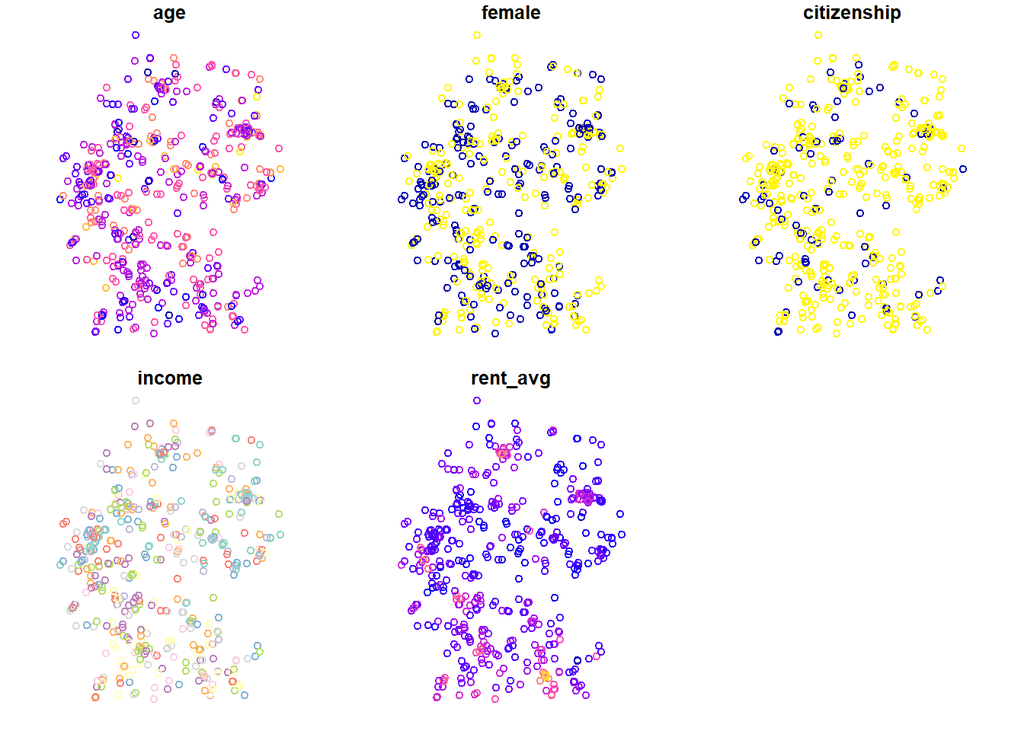

**Tip✅ Solution 3**

```r
# Step 1: Check CRS of both datasets — they must match for a join!
sf::st_crs(points_sf)$epsg # points: EPSG 3035 (ETRS89-LAEA)
```

```
[1] 3035
```

```r
sf::st_crs(polygon_data)$epsg # polygons: different CRS
```

```
[1] 25832
```

```r
# Step 2: Reproject points to match the polygon CRS
# (We transform the points because they're lighter than polygons)
points_transformed <-
  sf::st_transform(points_sf, crs = sf::st_crs(polygon_data))

# Step 3: Spatial join — adds AGS (district code) to each point
# based on which polygon it falls into
points_with_AGS <- sf::st_join(points_transformed, polygon_data[, "AGS"])

# Check: each point should now have an AGS value
head(points_with_AGS)
```

```
Simple feature collection with 6 features and 6 fields
Geometry type: POINT
Dimension:     XY
Bounding box:  xmin: 367922.1 ymin: 5708271 xmax: 829425.9 ymax: 5948916
Projected CRS: ETRS89 / UTM zone 32N
# A tibble: 6 × 7
    age female citizenship income      rent_avg           geometry AGS
  <dbl>  <dbl>       <dbl> <chr>          <dbl>        <POINT [m]> <chr>
1    51      1           0 2500-3000 €     6.21 (540828.5 5857602) 03358
2    36      0           1 1000-1500 €     5.44 (367922.1 5708271) 05513
3    47      1           1 1500-2000 €     5.35 (380782.8 5718445) 05562
4    51      0           0 2000-2500 €     9.46 (564543.3 5948916) 01060
5    46      0           1 > 5000 €        6.81 (829425.9 5819662) 12067
6    45      1           1 4000-4500 €     5.70 (472899.1 5781689) 05758
```